# Simple Linear Regression II

```r
library(dplyr)
library(ggplot2)
twins <- read.csv("http://andrewpbray.github.io/data/twins.csv")
options(scipen = 99)
```

1. Create a plot of the relationship between the IQs of the two children and describe the relationship in words (there is no clear independent variable here, so just put `Biological` on the x-axis).

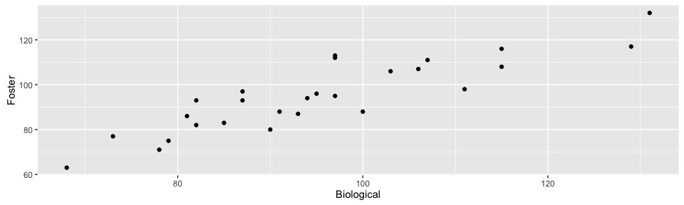

```r
qplot(x = Biological, y = Foster, data = twins, geom = "point")
```

*There is a positive, linear, moderately strong relationship between the IQs of the biological and the foster twins.*

2. Fit a linear model to this data and have a look at the summary of the model. Which one of the following is *false* and why?
   - For each 10 point increase in the biological twin’s IQ, we expect the foster twin’s IQ to increase on average by roughly 9 points.
   - The linear model (the estimated mean function) is approximately $\hat{y} = 9.2 + 0.9 \times x$.
   - Foster children with higher than average IQs (average of the foster children) will have biological twins with higher than average IQs as well (average of the biological children).

```r
m1 <- lm(Foster ~ Biological, data = twins)
summary(m1)$coef
```

```
##             Estimate Std. Error   t value        Pr(>|t|)
## (Intercept) 9.207599 9.29989643 0.9900754 0.3316237236298
## Biological  0.901436 0.09633286 9.3575128 0.0000000012036
```

*The fitted model makes it clear that both of the first statements are correct. The third statement is false because our model assumes that the data will have some vertical spread around this line because the normally distributed error will have some positive sigma (estimated in the regression summary as “residual standard error”). That means that it’s quite possible for a twin pair with a bio twin just below the average bio to have a foster twin that’s above the foster average. This would correspond to allowing for points to fall in the top left quadrant when the plot is divided by the vertical and horizontal lines corresponding to the two averages.

The third point is also wrong because it lacks the language of “tends” to be higher and could be interpretted as a causal relationship with no grounds.*

3. Is it reasonable to draw conclusions from this model? Assess the conditions for a valid model based on the context of this problem using appropriate plots.

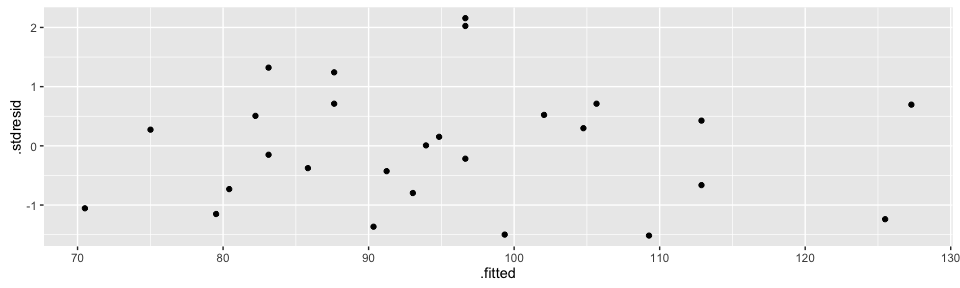

```r
qplot(x = .fitted, y = .stdresid, data = m1)
```

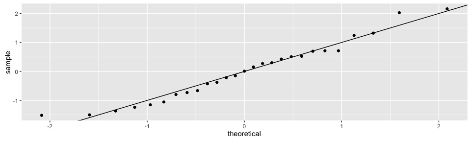

```r
qplot(sample = .stdresid, data = m1) + geom_abline()
```

*From the residual plot, we see that the assumption of constant variance is reasonable as the residuals are similarly spread around 0 for all values of the x. The assumption of linearity is also reasonable as the residuals are without any strong structure (and the previous scatterplot showed a linear trend). Regarding the independent errors, that assumption is probably also fine as long as the sampling method selected each twin pair independently of the others. Finally, the qqplot shows that the assumption of normality checks out since the points follow the identify line fairly closely.*

4. This study was used to weigh in on the question of whether IQ is a result of nature (your genes) or nurture (your environment). If IQ was purely a result of nurture, what slope would you expect to see in your linear model? Phrase that hypothetical question in terms of a hypothesis test and interpret the p-value in the context of this problem.

5. At the other end of the argument, the distribution of IQ might be entirely determined by genes. Use a 95% confidence interval on your slope to assess whether this claim is reasonable given your data set. (`?confint` may be helpful here.)

```r
(ci <- confint(m1))
```

```
##                  2.5 %    97.5 %
## (Intercept) -9.9458964 28.361094
## Biological   0.7030348  1.099837
```

*We are 95% confident that the true slope lies between 0.703 and 1.10. Since this interval includes 1, the claim that IQ is determined entirely by genes is plausible given this data.*

6. Now consider how the association between IQs would change if social class were taken into account. Create a plot to illustrate the relationship between all three variables (recall the use of the `color` argument). Just by looking at the plot (and without fitting any models), does it appear that the relationship between the IQs is the same for high social class children as it is for low social class children?

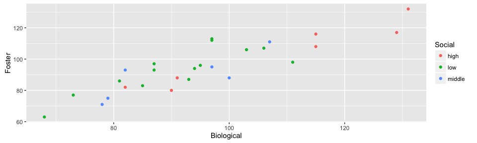

```r
qplot(x = Biological, y = Foster, color = Social, data = twins, geom = "point")
```

*This is really just an opinion question and multiple cases can be made.

I imagine that if you were to fit three lines to each group of points separately, `low` would have the steepest slope, `middle` would have the middle slope, and `high` would have the shallowest slope. This would correspond to the idea that there is in fact some influence of the environment, as the foster twin of the bio twin raised in a lower socio-economic level generally benefited more from their new environment as IQ increased. It’s difficult to tell based on this visualization if this effect statistically is significant.

The case could also be made based on the plot that the steepness of the lines is similar for all three groups.*

**Endnote**: The researcher that collected this data was named [Cyril Burt](http://en.wikipedia.org/wiki/Cyril_Burt), and his work was the subject of some controversy.

This lab was written for OpenIntro by Andrew Bray and Chester Ismay.